# 第8回 多変数関数の偏微分

経済学基礎数学II

第8回

多変数関数の偏微分

片方だけ動かす

経済学基礎数学II

第8回 — Topic01

東向きの傾きと北向きの傾き

山の斜面で、向きを決める

## 第8回の道のり

1

東と北の傾き

演習 1-1・1-2 丘の点 $(2, 1)$ の傾き

2

記号と計算の型

演習 2-1・2-2 $x$・$y$ で偏微分

演習 2-3 点での値

演習 2-4 $e$ と $\ln$

3

経済で使う

演習 3-1・3-2 限界の読み下し

演習 3-1・3-2 残りの $3$ 問

4

峠と二階

演習 4-1 $4$ 通りの二階

演習 4-1 残りの $2$ 問

演習 4-2 道具の見分け

いまココ — 前回は山を地図にした。今回は、その山に登る

## 前回の振り返り

前回のポイント — 多変数関数と可視化

Q: 変数が $2$ つの関数を、どうやって絵にしたか

- **$z = f(x, y)$**: 入れる数は $x$ と $y$、出る数は $z$
- **等高線**: 同じ標高の点をつないだ線。間隔がせまいほど急
- **切って見る**: 片方を止めると、$1$ 変数の関数に戻る

今回は、その山に **登る**

## 春の復習 ① 歩幅を縮めて出す傾き

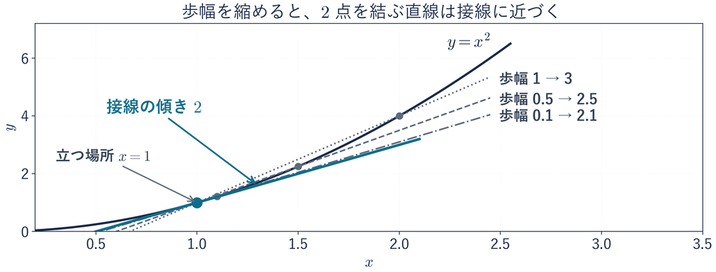

歩幅 $1$ の $3$ は、まだ傾きではない。縮めて近づいた $2$ が、接線の傾き

## 春の復習 ② 使う $6$ 本の公式

今回の計算は、春に習ったこの $6$ 本で足りる

| 名前 | 公式 | 例 |
| --- | --- | --- |
| $n$ 乗 | $(x^n)' = nx^{n-1}$ | $(x^3)' = 3x^2$ |
| 線形性 | $(af+bg)' = af'+bg'$ | $(3x^2+5x)' = 6x+5$ |
| 積 | $(fg)' = f'g+fg'$ | $(x^2e^x)' = 2xe^x+x^2e^x$ |
| 合成 | $\{f(g(x))\}' = f'(g(x))\,g'(x)$ | $\{(3x+1)^5\}' = 15(3x+1)^4$ |
| 指数 | $(e^x)' = e^x$ | $(e^{2x})' = 2e^{2x}$ |
| 対数 | $(\ln x)' = \frac{1}{x}$ | $(\ln 3x)' = \frac{1}{x}$ |

定数を微分すると $0$ 読み方は $\ln$ が「エルエヌ」、$e$ が「イー」

## 止めると $1$ 変数に戻る断面

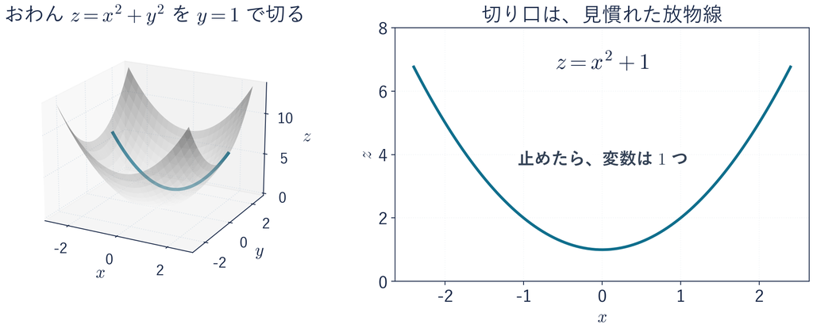

$y$ を $1$ に止めた瞬間、$z = x^2 + 1$ 今回は、この切り口の **傾き** を出す

## このトピックで学ぶこと

- **向きが要る**：傾きは、向きを決めないと $1$ つに決まらない
- **東と北**：無数の向きのうち、まずこの $2$ つだけ測る
- **歩幅を縮める**：表から出した差は、まだ傾きではない
- **相手を止める**：東へ歩くあいだ、北の座標は動かない

変数が $2$ つになると、向きの数だけ傾きがある

## ここからの山登り

斜面に立って「そこの傾きは、いくつですか」と聞かれた。  
**この問いには答えられない**

- **春の道具**：グラフの上の道は $1$ 本。傾きは $1$ つに決まった
- **斜面では**：同じ場所から、東へも北へも、どの向きへも歩ける
- **だから**：向きを決めて、$1$ 歩でどれだけ上り下りするかを数で出す

同じ場所でも、東へ $1$ 歩と北へ $1$ 歩では下り方が違う。  
向きを聞かないと決まらない

## 登山のことばと数学のことば

| 登山のことば | 数学のことば |
| --- | --- |
| 山 | $2$ 変数関数 $z = f(x, y)$ |
| 地図 | $xy$ 平面 |
| 等高線 | $f(x, y)$ が一定の線 |
| いま立っている場所 | 点 $(x, y)$ |
| 標高 | $z$ の値 |
| 真東へ $1$ 歩あたりの登り具合 | $x$ 方向の傾き |
| 真北へ $1$ 歩あたりの登り具合 | $y$ 方向の傾き |

東は $x$ の正の向き、北は $y$ の正の向き  
ここから先は「$x$ 方向の傾き」「$y$ 方向の傾き」と呼ぶ

## $x$ 方向と $y$ 方向で違う下り方

[figure not shown]

点 $(1, 2)$ に立つ。北（$y$ 方向）へ $1$ 歩のほうが、等高線を早くまたぐ

## $1$ 歩ずつ動いた表

丘 $h(x, y) = 10 - x^2 - y^2$ $h$ はその地点の標高。点 $(1, 2)$ では $h(1, 2) = 5$

| $y \backslash x$ | $0$ | $1$ | $2$ |
| --- | --- | --- | --- |
| $3$ | $1$ | $0$ | $-3$ |
| $2$ | $6$ | ↑**$5$**→ | $2$ |
| $1$ | $9$ | $8$ | $5$ |

$x$ 方向へ $1$ 歩：$5 \to 2$ で $3$ 下がる $y$ 方向へ $1$ 歩：$5 \to 0$ で $5$ 下がる

## ◼ 表で傾きを見つける $3$ STEP

式を使わず、表と割り算だけで傾きに近づく道

1. **立つ場所を決めて、標高を出す**
2. **$x$ 方向・$y$ 方向へ $1$ 歩ぶんの変化を、表にする**
3. **歩幅を縮めて、近づいていく数を読む**

STEP 3 まで行かないと傾きにならない。$3$ と $5$ は、まだ途中の数

## 歩幅を縮めて近づく $1$ つの数

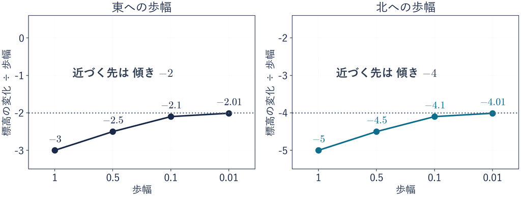

歩幅 $0.5$ の例（$x$ 方向）：$h(1.5,\ 2) = 10 - 2.25 - 4 = 3.75$  
$1$ 歩あたりに直す：$(3.75 - 5) \div 0.5 = -2.5$

$x$ 方向は $-2$ $y$ 方向は $-4$ この $2$ つが、点 $(1, 2)$ での傾き

## 表の要らない止め方

$h(x, y)$

$= 10 - x^2 - y^2$

丘の式

$\Downarrow$

$x$ 方向へ歩くあいだ $y$ は $2$ のまま

$h(x, y{=}2)$

$= 10 - x^2 - 4$

動かない $y^2$ は定数の $4$

$= 6 - x^2$

これを $g(x)$ と置く

$g'(x)$

$= -2x$

春の $n$ 乗と線形性で微分

$g'(x{=}1)$

$= -2$

$x = 1$ を入れる。$x$ 方向の傾き

$y$ 方向も同じ $h(x{=}1, y) = 9 - y^2 \;\to\; -2y \;\to\; -4$  
表で読んだ数に、ぴたりと合う

## $x$ 方向（東西）と $y$ 方向（南北）の断面

[figure not shown]

三角形の縦辺は $-2$ と $-4$ 同じ横 $1$ でも、落ち方が違う

## デモ：切って、回してみる

数の話

丘：$h = 10 - x^2 - y^2$ おわん：$z = x^2+y^2$  
板：$z = 2x+3y$

- **何を見るか**：止めて切った線が $1$ 変数の関数に戻ること
- **図の意味**：橙：$y = 2$、青緑：$x = 1$ で止めた切り口
- **操作**：右の柱のタブ $3$ つと「回す」。ドラッグでも回る

ミッション $y = 2$ の切り口が放物線 $1$ 本に見えるまで回す

※ 次のスライドへ進むときは、デモの枠の外を一度クリックしてから ← → キーを押す

[interactive chart not shown]

## ⚠ よくある $3$ つの取り違え

✕ こうしがち

向きを言わずに  
「この山の傾き」と言う

表の $-3$ を  
そのまま傾きと呼ぶ

$y = 2$ を入れたのに $-y^2$ を  
残して $-2x - 2y$ と書く

○ 正しくは

$x$ 方向の傾き・$y$ 方向の傾き  
**向きを付けて呼ぶ**

$-3$ は歩幅 $1$ の値  
縮めると $-2$

$-y^2 = -4$ は定数なので消える  
残るのは $6 - x^2$、微分して $-2x$

迷ったら、式に $1$ 組の数を入れてたしかめる

## 記号のまま止めた式

定義 — 偏微分（へんびぶん）

片方の文字を**定数だと思って**、もう片方で微分すること

- **この丘でやると**：$y$ を定数だと思って $x$ で微分すると、  
  $x$ 方向の傾きは $-2x$（例：$x = 3$ なら $-6$）
- **$10$ は定数**：微分すれば $0$
- **$-y^2$ も定数**：$y$ を動かさないので $0$

立つ場所を変えても式は $1$ つ。数を入れるのは、いちばん最後でよい

## 演習 1-1・1-2 丘の点 $(2, 1)$ の傾き

演習 1-1・1-2

同じ丘 $h(x, y) = 10 - x^2 - y^2$ の、点 $(2, 1)$ に立つ

1. $y$ を止めた式と、そこでの $x$ 方向の傾き
2. $x$ を止めた式と、そこでの $y$ 方向の傾き

⏸ PAUSE 動画を止めて、ノートに $2$ 問とも解く。解けたら再生に戻る

## 演習 1-1 の答え — 問 $1$

**問 $1$** 点 $(2, 1)$ で、$y$ を止める

① 止める文字

$x$ 方向へ歩く  
動かないのは $y$

② $1$ 変数にする

$y = 1$ を入れて  
$h(x, y{=}1) = 10 - x^2 - 1$

③ 微分して数を入れる

微分して $-2x$  
$x = 2$ を入れる

こたえ

$h(x, y{=}1) = 9 - x^2$ $x$ 方向の傾きは $-4$（下り）

標高は $h(2, 1) = 5$ で、さっきの点 $(1, 2)$ の $5$ と同じ。それでも傾きは違う

## 演習 1-2 の答え — 問 $2$

**問 $2$** 同じ点 $(2, 1)$ で、今度は $x$ を止める

① 止める文字

$y$ 方向へ歩く  
動かないのは $x$

② $1$ 変数にする

$x = 2$ を入れて  
$h(x{=}2, y) = 10 - 4 - y^2$

③ 微分して数を入れる

微分して $-2y$  
$y = 1$ を入れる

こたえ

$h(x{=}2, y) = 6 - y^2$ $y$ 方向の傾きは $-2$（下り）

点 $(1, 2)$ では $y$ 方向が急で $-4$、点 $(2, 1)$ では $x$ 方向が急で $-4$。立つ場所で入れ替わる

## まとめ

- $2$ 変数関数の傾きは、向きを決めないと $1$ つに決まらない
- だから、まず $x$ 方向（東）と $y$ 方向（北）の $2$ つだけ測る
- 表から出した差は歩幅が大きすぎる。  
  差を歩幅で割って縮めると $-2$ と $-4$ に近づく
- $x$ 方向に歩くあいだ、$y$ は動かない。**動かない数は定数**
- 相手を定数だと思って微分すれば、式 $1$ つで済む。これが偏微分

**ドリル8 は次のトピックから**  
まず格子の表を自分で埋める → 次は「偏微分の記号と計算の型」

経済学基礎数学II

第8回 — Topic02

偏微分の記号と計算の型

春の公式がそのまま効く

## 第8回の道のり

1

東と北の傾き

演習 1-1・1-2 丘の点 $(2, 1)$ の傾き

2

記号と計算の型

演習 2-1・2-2 $x$・$y$ で偏微分

演習 2-3 点での値

演習 2-4 $e$ と $\ln$

3

経済で使う

演習 3-1・3-2 限界の読み下し

演習 3-1・3-2 残りの $3$ 問

4

峠と二階

演習 4-1 $4$ 通りの二階

演習 4-1 残りの $2$ 問

演習 4-2 道具の見分け

いまココ — ここから、手が動くようになる

## このトピックで学ぶこと

- **偏微分の感覚**：相手の文字は定数。動くのは $1$ 文字だけ
- **記号 $\partial$ と近道**：数を入れる遠回りを、記号と近道に置きかえる
- **点での値**：微分が先、代入が後
- **$e$ と $\ln$ も同じ**：春の公式がそのまま効く

新しい公式は $1$ つも要らない

## 偏微分の意味と $2$ STEP

用語

**偏微分**：相手の文字を定数だと思い、  
$1$ つの文字だけを動かして微分すること

「相手」とは、微分しないほうの文字。$x$ で偏微分するなら、相手は $y$

STEP 1動かさない文字を決めて、数字だと思う（$y$ を $3$ だと思う）

STEP 2春の公式で微分し、数字だと思った文字を書き戻す

足すのは「相手を数字だと思う」の一手だけ

## 数を入れる遠回り

$f(x, y) = 3x^2 + 5xy + 2y^3$ を $x$ で偏微分する

STEP 1

$f(x,\, y{=}3)$

$= 3x^2 + 5x \cdot ({\color{#fb923c}3}) + 2 \cdot ({\color{#fb923c}3})^3$

$y$ を $3$ だと思う。  
まとめない

$= g(x)$

$x$ だけの関数。  
$g(x)$ とおく

STEP 2

$g'(x)$

$= 6x + 5 \cdot ({\color{#fb923c}3}) + 0$

春の公式。$2 \cdot (3)^3$ はただの数

書き戻す

$= 6x + 5y$

入れた $({\color{#fb923c}3})$ を $y$ に戻す

橙の $3$ は入れた数。$3x^2$ の $3$ とは別物。最後に $y$ へ戻す

## 記号 $\partial$ の意味

毎回「$y$ を $3$ にして $x$ で微分した」と書くのは長い。短い記号を決める

用語

$\frac{\partial f}{\partial x}$：$y$ を定数だと思って、$f$ を $x$ で微分したもの

- **読み方は $3$ つある**：**ラウンド**・デル・パーシャル

この授業では「ラウンド」で通す：$\frac{\partial f}{\partial x}$ は「ラウンド エフ、ラウンド エックス」

- **$\partial$ の意味**：「相手は止めてあります」という印。それだけ
- **なぜ $d$ でないか**：$d$ は変数が $1$ つのときの印。$\partial$ は相手がいる印

さっきの答えは $\frac{\partial f}{\partial x} = 6x + 5y$ と書く

## 遠回りと近道

同じ $f(x, y) = 3x^2 + 5xy + 2y^3$ を $x$ で偏微分する

遠回り

$y$ に $3$ を入れて微分し  
最後に $3$ を $y$ に戻す

$6x + 5 \cdot (3) \;\to\; 6x + 5y$

近道

$y$ のまま、定数だと思う  
$3x^2 \to 6x$ $5xy \to 5y$ $2y^3 \to 0$

$6x + 5y$

どちらも $\frac{\partial f}{\partial x} = 6x + 5y$  
$y$ でも同じ。$x$ を定数だと思うと $\frac{\partial f}{\partial y} = 5x + 6y^2$

慣れたら遠回りは頭の中だけ。迷ったら $3$ を入れて確かめる

## ⚠ いちばん多い間違い

✕ こうしがち

$x$ で偏微分するのに  
$3y^4$ を $12y^3$ と書く

$5xy$ を $x$ で偏微分して  
$5$ と書く

○ 正しくは

相手だけの項は $0$  
$4x^3 + 3y^4$ の答えは $12x^2$

相手は係数として残る  
答えは $5y$

迷ったら遠回り：$5xy$ の $y$ を $3$ → $15x$ → $15 = 5 \cdot 3$ → $5y$

## 演習 2-1・2-2 $x$ で偏微分・$y$ で偏微分

演習 2-1・2-2 ／ 計算ドリル8

ブロック $1$・$2$ の全問。動画の答え合わせは各ブロックの 問 $1$

**演習 2-1** ブロック $1$・$x$ で偏微分

- **復習 A** $f(x) = 4x^3 + 3$ の $f'(x)$
1. $f(x, y) = 4x^3 + 3y^4$
2. $f(x, y) = 4x^2 + 9xy$
3. $f(x, y) = 3x^4 + 5y + 8$
4. $f(x, y) = 6xy + y^2$
5. $f(x, y) = 5x^2y + 4y$

**演習 2-2** ブロック $2$・$y$ で偏微分

- **復習 B** $f(x) = 8x + 2x^4$ の $f'(x)$
1. $f(x, y) = 7x^2 + 3y^3$
2. $f(x, y) = 8xy + 2y^4$
3. $f(x, y) = 4x^3 + 2y^5$
4. $f(x, y) = 5xy + 3x^2$
5. $f(x, y) = 3xy^2 + 2x$

⏸ PAUSE 動画を止めて、ノートに全部解く。2-1・2-2 の 問 $1$ が解けたら再生に戻る  
復習も解く。解説しない問題は、配った答えで確かめる

## 演習 2-1 の答え — 問 $1$

**問 $1$** $f(x, y) = 4x^3 + 3y^4$

STEP 1 数字だと思う

$y$ を $3$ だと思うと  
$3y^4$ は、ただの数

STEP 2 春の公式で微分

$4x^3$ は $12x^2$  
ただの数は $0$

こたえ

$\frac{\partial f}{\partial x} = 12x^2$

$12y^3$ を足してはいけない。$y$ だけの項は、消える

## 演習 2-2 の答え — 問 $1$

**問 $1$** $f(x, y) = 7x^2 + 3y^3$

STEP 1 数字だと思う

今度は $x$ を数字だと思う  
$7x^2$ は、ただの数

STEP 2 春の公式で微分

$3y^3$ は $9y^2$  
ただの数は $0$

こたえ

$\frac{\partial f}{\partial y} = 9y^2$

$14x$ は、$x$ で偏微分したときの答え。聞かれているのは $y$ のほう

## 偏導関数と偏微分係数

[figure not shown]

左を **偏導関数**、右を **偏微分係数** という。  
春の導関数と微分係数の使い分けと同じ

## 点での値の見本

$f(x, y) = 3x^2 + 5xy + 2y^3$ の、点 $(2, 1)$ での $\frac{\partial f}{\partial x}$ と $\frac{\partial f}{\partial y}$ の値

STEP 1

$\frac{\partial f}{\partial x}$

$= 6x + 5y$

先に偏微分。$y$ を定数だと思う

$\frac{\partial f}{\partial y}$

$= 5x + 6y^2$

$x$ を定数だと思う

STEP 2

$\frac{\partial f}{\partial x}(2, 1)$

$= 6 \cdot 2 + 5 \cdot 1 = 17$

点を入れる。前が $x = 2$、  
後ろが $y = 1$

$\frac{\partial f}{\partial y}(2, 1)$

$= 5 \cdot 2 + 6 \cdot 1^2 = 16$

同じ点を入れる

⚠ 先に $(2, 1)$ を入れると $f(2, 1) = 24$ というただの数。  
微分すると $0$. 微分が先、代入が後

## 演習 2-3 点での値

演習 2-3 ／ 計算ドリル8

ブロック $3$ の全問。$x$ で偏微分・$y$ で偏微分して、  
指定された点での値を求める

- **復習 D** $f(x) = 3x^2$ の $f'(x)$ と $f'(2)$
1. $f(x, y) = 3x^2 + 5y^2$, 点 $(2, 1)$
2. $f(x, y) = 4xy - y^2$, 点 $(5, 2)$
3. $f(x, y) = 2x^2 + xy$, 点 $(1, 3)$
4. $f(x, y) = x^3 + 2y^2$, 点 $(2, 1)$
5. $f(x, y) = 5xy + y^3$, 点 $(3, 1)$

⏸ PAUSE 動画を止めて、ノートに全部解く。解いたら再生に戻る  
復習も解く。動画では解説しない。答えは配った答えで確認

## $e$ と $\ln$ が入った形

$e$ と $\ln$ が付いても、相手は定数。  
前に出てきた $(e^x)' = e^x$ と $(\ln x)' = \frac{1}{x}$ がそのまま効く

$f = 4e^x + y^3$

$x$ で：$y^3$ は定数 → $\frac{\partial f}{\partial x} = 4e^x$  
$y$ で：$4e^x$ は定数 → $\frac{\partial f}{\partial y} = 3y^2$

$f = 5\ln x + 2\ln y$

$x$ で：$2\ln y$ は定数 → $\frac{\partial f}{\partial x} = \frac{5}{x}$  
$y$ で：$5\ln x$ は定数 → $\frac{\partial f}{\partial y} = \frac{2}{y}$

$e^y$ を $x$ で偏微分すると $0$. $e$ が付いていても、$x$ が入っていなければ定数

## 中身が $1$ 次式の合成関数

春の合成 $\{f(g(x))\}' = f'(g(x))\,g'(x)$ のまま。  
中身 $g$ も、相手を止めて偏微分する

$x$ で偏微分する

中身 $2x + 3y$ を  
$x$ で偏微分すると $2$  
$\frac{\partial}{\partial x}e^{2x+3y} = 2e^{2x+3y}$

$y$ で偏微分する

中身 $2x + 3y$ を  
$y$ で偏微分すると $3$  
$\frac{\partial}{\partial y}e^{2x+3y} = 3e^{2x+3y}$

かかっている数が $1$ なら、前に出るのも $1$：$e^{x+5y}$ を $x$ で偏微分すると $e^{x+5y}$

外を微分して、内の係数を掛ける。$e$ の部分は、そのまま残る

## かけ算でも相手は係数

決め手：微分する文字が、かけ算の片方にしか無い

$x^2e^y$ を $x$ で

$e^y$ は定数。「数 $\times\, x^2$」の形

$\frac{\partial f}{\partial x} = 2xe^y$

$x^2e^y$ を $y$ で

$x^2$ は定数。「数 $\times\, e^y$」の形

$\frac{\partial f}{\partial y} = x^2e^y$

⚠ かけ算を見たら積の微分、ではない。同じ式でも、  
残る文字が入れ替わるだけ

## 演習 2-4 $e$ と $\ln$

演習 2-4 ／ 計算ドリル8

ブロック $4$ の全問。$x$ と $y$ それぞれで偏微分。  
動画の答え合わせは 問 $1$

- **復習 C**  
  $f(x) = 5e^x$ と $g(x) = 4\ln x$ の微分
1. $f(x, y) = 5e^x + 3y^2$
2. $f(x, y) = 4\ln x + 3\ln y$
3. $f(x, y) = x^3 + 2e^y$
4. $f(x, y) = e^{4x+y}$
5. $f(x, y) = e^{x+5y}$

⏸ PAUSE 動画を止めて、ノートに全部解く。2-4 の 問 $1$ が解けたら再生に戻る  
復習も解く。解説しない問題は、配った答えで確かめる

## 演習 2-4 の答え — 問 $1$

**問 $1$** $f(x, y) = 5e^x + 3y^2$

STEP 1 数字だと思う

$x$ で偏微分するなら $3y^2$ が数  
$y$ で偏微分するなら $5e^x$ が数

STEP 2 春の公式で微分

$(e^x)' = e^x$ と  
$(y^2)' = 2y$ を当てる

こたえ

$\frac{\partial f}{\partial x} = 5e^x$ $\frac{\partial f}{\partial y} = 6y$

新しい公式は使っていない。春の $(e^x)' = e^x$ が、そのまま効いている

## まとめ

- 偏微分：相手の文字は定数。動くのは $1$ 文字だけ
- 遠回り（数を入れる）と近道（定数だと思う）は、同じ答え
- $\frac{\partial f}{\partial x}$ は「相手は止めてあります」の印
- 点での値は、微分が先、代入が後
- $e$・$\ln$・合成も、春と同じ微分のまま。かけ算でも相手は係数

演習のページの残りの問題（**計算ドリル8 のブロック $1$〜$4$**）を解く  
→ 次は「経済で使う」

経済学基礎数学II

第8回 — Topic03

限界生産力と限界効用

もう 1 つ増やしたら、どれだけ増えるか

## 第8回の道のり

1

東と北の傾き

演習 1-1・1-2 丘の点 $(2, 1)$ の傾き

2

記号と計算の型

演習 2-1・2-2 $x$・$y$ で偏微分

演習 2-3 点での値

演習 2-4 $e$ と $\ln$

3

経済で使う

演習 3-1・3-2 限界の読み下し

演習 3-1・3-2 残りの $3$ 問

4

峠と二階

演習 4-1 $4$ 通りの二階

演習 4-1 残りの $2$ 問

演習 4-2 道具の見分け

いまココ — 機械と人のどちらを増やすか、偏微分で比べる

## このトピックで学ぶこと

- **限界は復習**：前に出てきた  
  「もう $1$ つ増やしたら、およそどれだけ」と同じ
- **$2$ 変数で言えること**：機械と働き手、どちらを増やすほうが効くか
- **限界生産力・限界効用**：工場の生産と、りんごの満足で読む
- **およそ・逓減**：傾きは目安。増やすほど、  
  追加 $1$ つの効き目が落ちる

新しい計算は無い。$2$ 変数なら「どちらを増やすか」の比較まで

## 復習 前に出てきた「限界」

用語 — 「限界」

経済の「限界」は、**もう $1$ つ増やしたときの、およその増え方**

- **前に出てきた**：限界費用は  
  「もう $1$ 個作るのに、およそいくらかかるか」だった
- **正体は傾き**：グラフの傾きに、経済の名前を付けただけ
- **変数が $2$ つになると**：増やすものを $1$ つ決めて、相手は止める

「限界」と聞いたら、傾きだと読み替える

## 前に出てきた工場とりんご・みかん

前に出てきた $2$ つの式を、そのまま持ってくる

| 何の式 | 式 | 入れる数 | 出る数 |
| --- | --- | --- | --- |
| 生産関数 | $Y = \sqrt{KL}$ | 機械 $K$ 台・ 働き手 $L$ 人 | 生産 $Y$ 個 |
| 効用関数 | $u = xy$ | りんご $x$ 個・ みかん $y$ 個 | 満足 $u$（単位 は無い） |

前に出てきた工場は 機械 $4$ 台・働き手 $9$ 人 生産は $Y = \sqrt{36} = 6$ 個

## $2$ 変数で比べる理由

工場の生産は、機械と働き手の $2$ つで決まる  
だから「どちらを増やすか」を比べたい

- **$1$ 変数では**：「機械を増やすと、生産が増える」まで
- **$2$ 変数なら**：機械 $1$ 台と働き手 $1$ 人、  
  どちらが生産を多く増やすかの比較
- **使う計算**：前のトピックの $2$ STEP（偏微分）。新しい計算は無い

相手を止めて $1$ つずつ増やす。偏微分が、この問いに答える

## いま立っている工場

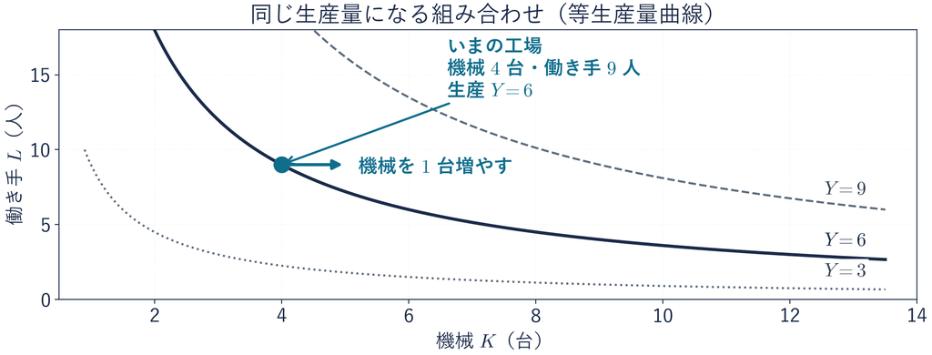

機械 $4$ 台・働き手 $9$ 人 ここから、機械だけ $1$ 台増やしてみる

## 春の復習 ③ 根号と分数の肩の形

春の $n$ 乗の公式が使えるのは、**肩に数が乗った形**  
$\sqrt{\;}$ は「$\frac{1}{2}$ 乗」の別名、マイナスの肩は「分母へ行く」印

| もとの形 | $\sqrt{9}$ | $\sqrt{2}$ | $\frac{1}{x}$ | $\frac{1}{\sqrt{x}}$ | $\sqrt{KL}$ |
| --- | --- | --- | --- | --- | --- |
| **肩の形** | $9^{1/2} = 3$ | $2^{1/2}$ | $x^{-1}$ | $x^{-1/2}$ | $K^{1/2}L^{1/2}$ |

肩の形にすれば、春の $n$ 乗がそのまま効く（$(x^{1/2})' = \frac{1}{2}x^{-1/2} = \frac{1}{2\sqrt{x}}$）

公式は春の $6$ 本のまま。足すのは**肩の書き換え**だけ

## 限界生産力の計算

用語 — 機械の限界生産力

$\frac{\partial Y}{\partial K}$ — 働き手を止めて、機械をもう $1$ 台入れたときの、  
生産のおよその増え方（**機械 $1$ 台あたり ◯ 個**）

$\frac{\partial Y}{\partial K}$

$= \frac{1}{2}K^{-1/2}L^{1/2}$

$Y = K^{1/2}L^{1/2}$. $L$ は定数、春の $n$ 乗

$= \frac{1}{2}\sqrt{\frac{L}{K}}$

マイナスの肩を分母へ戻して、まとめる

$= \frac{1}{2}\sqrt{\frac{9}{4}} = \frac{1}{2} \times \frac{3}{2} = 0.75$

$K = 4,\ L = 9$ を入れる

働き手は $K$・$L$ が入れ替わり $\frac{\partial Y}{\partial L} = \frac{1}{2}\sqrt{\frac{4}{9}} \approx 0.33$ 機械の $0.75$ のほうが効く

## ◼ 限界を読む $3$ STEP

計算ドリル8 のブロック $5$ も、この番号で並んでいる

1. **偏微分する**（前のトピックの $2$ STEP）
2. **いまの点の数を入れて、値を出す**（使わない数があってもよい）
3. **「◯を $1$ つ増やすと、△がおよそ□増える」と日本語に直す**

STEP 3 まで行って、はじめて経済の答えになる

## 「およそ」が要る理由

[figure not shown]

傾きは 機械 $1$ 台あたり $0.75$ 個  
実際に $1$ 台増やすと、生産は $6$ → 約 $6.71$ 個。増えるのは 約 $0.71$ 個

## 機械だけ動かす $1$ 変数のグラフ

[figure not shown]

働き手は $9$ 人のまま。右へ行くほど、上がる高さが短くなる  
$K = 4$ から $4$ 台ぶんの見込みは $3$、実際は 約 $2.49$

## 増やすほど落ちる効き目

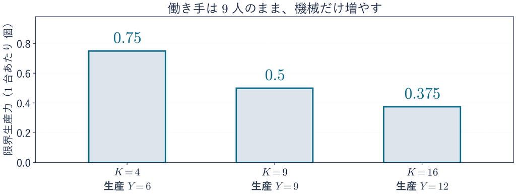

- **逓減**（ていげん）：増やすほど、追加 $1$ つの効き目が落ちること
- グラフでは **右へ行くほど傾きがゆるくなる**  
  （$(\ln x)' = \frac{1}{x}$ も、右へ行くほど小さくなる）
- **機械 $16$ 台では**：働き手 $1$ 人で 約 $0.67$ 個 ＞ 機械 $1$ 台で $0.375$ 個

## りんごをもう $1$ 個食べたら

用語 — 限界効用

$\frac{\partial u}{\partial x}$ — みかんを止めて、りんごをもう $1$ 個食べたときの、  
満足のおよその増え方

- **効用が $u = xy$ なら**：りんごの限界効用は $\frac{\partial u}{\partial x} = y$
- **答えに $y$ が残る**：この効用関数では、みかんが多い人ほど、  
  りんご $1$ 個の値打ちが大きい
- **満足に単位は無い**：$u = 32$（りんご $4$・みかん $8$）は  
  「$32$ 円ぶん嬉しい」ではない

使い道：りんごをもう $1$ 個買うか迷うとき、満足がどれだけ増えるかの目安

## ⚠ 読み下しのつまずき

✕ こうしがち

$0.75$ を「$1$ 台増やした  
ときの増分そのもの」と思う

「限界生産力は $0.75$」  
で止める

満足の大きさに  
円をつける

○ 正しくは

$0.75$ は「増え方の目安」  
実際は 約 $0.71$ 個

**機械 $1$ 台あたり $0.75$ 個**  
単位まで言う

$u$ に単位は無い  
くらべるためだけの数

数を出しただけでは、まだ答えになっていない

## 演習 3-1・3-2 限界の読み下し

演習 3-1・3-2 ／ 計算ドリル8

ブロック $5$ の前半 $2$ 問。動画で答え合わせする

- **復習 E** $\sqrt{x}$ を $x$ の何乗かの形で書き、微分する
1. 満足が $u(x, y) = 5x^2 + 6xy$（りんご $x$ 個・みかん $y$ 個）  
   (1) りんごの限界効用 (2) みかんの限界効用
2. 別の人の満足が $u(x, y) = 12\ln x + 8\ln y$（$x > 0$, $y > 0$）  
   (1) りんごの限界効用 (2) りんごが $3$ 個と $6$ 個での値  
   (3) りんごが増えると、$1$ 個の値打ちは

⏸ PAUSE 動画を止めて、復習と問 $1$・問 $2$ をノートに解く。解けたら再生に戻る  
復習は、配った答えで確かめる

## 演習 3-1 の答え — 問 $1$

**問 $1$** $u(x, y) = 5x^2 + 6xy$

STEP 1 偏微分する

$x$ で微分: $10x + 6y$  
$y$ で微分: $6x$

STEP 2 数を入れる

点は指定されていない  
式のままが答え

STEP 3 日本語に直す

りんごをもう $1$ 個で  
満足はおよそ  
$10x + 6y$ 増える

こたえ

$\frac{\partial u}{\partial x} = 10x + 6y$ $\frac{\partial u}{\partial y} = 6x$

答えに $y$ が残る。この効用関数では、  
みかんを多く持つ人ほど、りんご $1$ 個の値打ちが大きい

## 演習 3-2 の答え — 問 $2$

**問 $2$** $u(x, y) = 12\ln x + 8\ln y$

STEP 1 偏微分する

$8\ln y$ は定数で $0$  
$(\ln x)' = \frac{1}{x}$ を使い  
$12 \times \frac{1}{x} = \frac{12}{x}$

STEP 2 数を入れる

$x = 3$ なら $\frac{12}{3} = 4$  
$x = 6$ なら $\frac{12}{6} = 2$

STEP 3 日本語に直す

りんごが増えるほど  
$1$ 個の値打ちは  
小さくなる

こたえ

$\frac{\partial u}{\partial x} = \frac{12}{x}$ $3$ 個で $4$ $6$ 個で $2$

これも逓減。満足の大きさなので、値に単位は書かない

## 演習 3-1・3-2 の残りの $3$ 問

演習 3-1・3-2 ／ 計算ドリル8

ブロック $5$ の後半 $3$ 問。動画では解説しない

3. 機械 $K$ 台・働き手 $L$ 人で $Y = 3KL + L^2$（個）、いま $K = 2$, $L = 5$  
   (1) 機械の限界生産力 (2) その点での機械と働き手の限界生産力  
   (3) $1$ つだけ増やすなら、どちらが生産を大きく増やすか
4. 機械 $K$ 台・働き手 $L$ 人で $Y = \sqrt{KL}$（個）、いま $K = 4$, $L = 25$  
   (1) 機械の限界生産力 (2) その値 (3) 「機械をもう $1$ 台入れると、…」の $1$ 文
5. 満足が $u(x, y) = 4xy$ のとき、りんご $3$ 個・みかん $5$ 個での、りんごの限界効用

⏸ PAUSE 動画を止めて、ノートに $3$ 問とも解く。解けたら再生に戻る  
この $3$ 問は動画で解説しない。配った答えで確かめる

## まとめ

- $2$ 変数の「限界」は、偏微分して出た数のこと。読み下しは $3$ STEP
- **$2$ 変数だから**：機械と働き手、どちらを増やすほうが効くかの比較
- **限界生産力・限界効用**：もう $1$ つ増やしたときの、  
  生産・満足のおよその増え方
- 「およそ」を落とさない。目安の $0.75$ と、実際の 約 $0.71$ は違う
- 増やすほど効き目が落ちることを **逓減** という  
  （工場の機械・$\ln$ の満足がその例）

偏微分で、どれを増やすと効くかを比べられた  
では、傾きが両方 $0$ の場所は、いつも山頂なのか  
→ 次のトピック「峠と二階の偏導関数」で見る

経済学基礎数学II

第8回 — Topic04

峠と二階の偏導関数

向きで、登りにも下りにもなる

## 第8回の道のり

1

東と北の傾き

演習 1-1・1-2 丘の点 $(2, 1)$ の傾き

2

記号と計算の型

演習 2-1・2-2 $x$・$y$ で偏微分

演習 2-3 点での値

演習 2-4 $e$ と $\ln$

3

経済で使う

演習 3-1・3-2 限界の読み下し

演習 3-1・3-2 残りの $3$ 問

4

峠と二階

演習 4-1 $4$ 通りの二階

演習 4-1 残りの $2$ 問

演習 4-2 道具の見分け

いまココ — 向きで登りにも下りにもなる場所を、向きごとの傾きで読む

## このトピックで学ぶこと

- **峠**：まわりに $x$ 方向は登り、$y$ 方向は下りの場所がある。  
  だから向きごとの傾き（偏微分）で読む
- **鞍点**：$x$ 方向も $y$ 方向も傾き $0$ なのに、山頂でも谷底でもない点
- **二階**：偏微分した式を、もう一度偏微分する。  
  $x$ 方向・$y$ 方向の曲がり方（上に凸・下に凸）が分かる
- **交差は同じ**：$x$ と $y$ で $1$ 回ずつ偏微分した $2$ つは、  
  この授業の関数なら同じ数

傾きが $0$ でも、山頂とはかぎらない

## 前に出てきた $2$ 方向

トピック1 の丘 $h = 10 - x^2 - y^2$ を、点 $(1, 2)$ で測った

| 向き | 止める文字 | 切り口 | そこでの傾き |
| --- | --- | --- | --- |
| $x$ 方向 | $y = 2$ | $6 - x^2$ | $-2$ |
| $y$ 方向 | $x = 1$ | $9 - y^2$ | $-4$ |

このときは、どちらも下りだった。  
今回は **片方が登りで、片方が下り** の場所を見る

## 前に出てきた鞍と春の二階微分

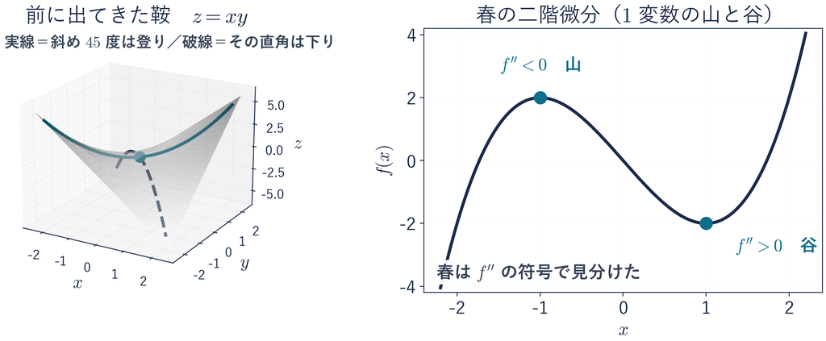

春は $f''$ の符号で、上に凸（山）か下に凸（谷）かを見分けた

## ここから立つ峠

峠は、鞍の真ん中の点。そのまわりには  
$x$ 方向は登り、$y$ 方向は下りになる場所がある

- **何をやるか**：峠のまわりの斜面を、$2$ つの偏微分の符号で読む
- **どこで要るか**：傾きが $0$ の場所が、山頂とはかぎらないから
- **もう $1$ つ**：もう一度偏微分する「二階」。曲がり方が分かる

向きで登りにも下りにもなる。だから傾きは、向きごとに偏微分で読む

## 峠のまわりの登りと下り

$z(x, y)$

$= x^2 - y^2$

地形の式。点 $(1, 1)$ に立つ

$\Downarrow$

$x$ 方向へ歩くあいだ $y$ は $1$ のまま

$z(x, y{=}1)$

$= x^2 - 1$

動かない $y^2$ は定数の $1$

$z_x(x, y{=}1)$

$= 2x$

$x$ で微分。$\frac{\partial z}{\partial x}$ を短く $z_x$ と書く

$z_x(x{=}1, y{=}1)$

$= 2$

$x = 1$ を入れる。**$x$ 方向は登り**

$y$ 方向も同じ $z(x{=}1, y) = 1 - y^2 \;\to\; z_y = -2y \;\to\; -2$ **$y$ 方向は下り**  
⚠ 点 $(1, 1)$ は峠そのものではない。傾きが、まだ $0$ になっていない

## 立体と地図で見る峠

[figure not shown]

峠は原点。東（$x$ 方向）も北（$y$ 方向）も、傾きが $0$

## 山でも谷でもない場所

用語 — 鞍点（あんてん）

$x$ 方向の傾きも $y$ 方向の傾きも $0$ なのに、  
山頂でも谷底でもない点

- **$y = 0$ で切ると（$x$ 方向）**：$z = x^2$ 原点がいちばん低い（谷の形）
- **$x = 0$ で切ると（$y$ 方向）**：$z = -y^2$ 原点がいちばん高い（山の形）
- **前に出てきた形**：鞍 $z = xy$ と同じ種類の形で、向きが $45$ 度違う

峠の真ん中の点が鞍点。山でも谷でもない第 $3$ の形

## デモ：等高線の型を見くらべる

数の話

$z = a x^2 + b y^2 + c xy$  
$a$・$b$・$c$ は $x^2$・$y^2$・$xy$ に掛ける数

- **何を見るか**：輪になる形と、  
  向かい合って開く線（高さ $0$ 以外は双曲線）のちがい
- **図の意味**：橙：正の高さ、青緑：負の高さ。数はその線の高さ
- **操作**：配ったスライドの次のページで、  
  右のタブ $4$ つとスライダ $3$ 本を動かす

ミッション 峠と鞍 $xy$ の、開く向きの $45$ 度ちがいの確認

※ 次のスライドへ進むときは、デモの枠の外を一度クリックしてから ← → キーを押す

[interactive chart not shown]

## ⚠ 傾き $0$ でも山頂でない点

✕ こうしがち

$x$ 方向も $y$ 方向も傾きが $0$  
だから山頂だと決める

向きで登り下りが違うのを  
計算ミスだと思う

点 $(1, 1)$ が峠だと言う

○ 正しくは

峠かもしれない  
$0$ だけでは決まらない

峠のまわりでは  
ふつうに起きる

傾きが $0$ でない  
峠は原点のほう

山頂か峠かは、**あとで道具をそろえて見分ける**

## ◼ 二階の偏導関数を作る $2$ STEP

定義 — 二階の偏導関数

$\frac{\partial^2 f}{\partial x^2} = \frac{\partial}{\partial x}\left(\frac{\partial f}{\partial x}\right)$ 短く $f_{xx}$（$2$ は $2$ 回の印）

- **意味**：傾きの変化率。$1$ 歩あたりの、傾きのおよその変わり方
- **読み方**：「ラウンド $2$ 乗 エフ、ラウンド エックス $2$ 乗」
- **分母は右から読む**：$\frac{\partial^2 f}{\partial x \partial y}$ は、**先に $y$、あとで $x$**（短く $f_{yx}$）
- **交差**：$x$ と $y$ を $1$ 回ずつ使う $2$ つ。この授業の関数なら同じ数
1. **一階の偏導関数を $2$ つ作る**（$x$ で $1$ つ、$y$ で $1$ つ）
2. **その $2$ つを、それぞれ $x$ と $y$ でもう一度偏微分する**

## $4$ 通りの二階

$f(x, y) = x^2y^3$ $x$ 方向の傾きは $f_x = 2xy^3$ $y$ 方向の傾きは $f_y = 3x^2y^2$

| 書き方 | どの傾きが・ どちらへ進むと | 微分して答え |
| --- | --- | --- |
| $\frac{\partial^2 f}{\partial x^2}$（$f_{xx}$） | $x$ 方向の傾きが $x$ 方向へ | $2xy^3$ を $x$ で → $2y^3$ |
| $\frac{\partial^2 f}{\partial y^2}$（$f_{yy}$） | $y$ 方向の傾きが $y$ 方向へ | $3x^2y^2$ を $y$ で → $6x^2y$ |
| $\frac{\partial^2 f}{\partial x \partial y}$（$f_{yx}$） | $y$ 方向の傾きが $x$ 方向へ | $3x^2y^2$ を $x$ で → $6xy^2$ |
| $\frac{\partial^2 f}{\partial y \partial x}$（$f_{xy}$） | $x$ 方向の傾きが $y$ 方向へ | $2xy^3$ を $y$ で → $6xy^2$ |

どれも「進むと、傾きがどう変わるか」。  
この授業の関数なら **交差の $2$ つは同じ数**

## 一階と二階のつながり

[figure not shown]

一階が $2$ つ、そこから $2$ つずつで $4$ 通り。交差の $2$ つは同じ数

## 二階が表す傾きの変わり方

[figure not shown]

$2x$ をもう一度 $x$ で微分して $\frac{\partial^2 z}{\partial x^2} = 2$ 正なので $x$ 方向（東）は下に凸

## 演習 4-1 $4$ 通りの二階

演習 4-1 ／ 計算ドリル8

ブロック $6$ の前半 $3$ 問。動画の答え合わせは 問 $1$

- **復習 F** $f(x) = x^3$ の $f'(x)$ と $f''(x)$

次の関数の、$4$ 通りの二階の偏導関数をすべて求める

1. $f(x, y) = 3x^2y$
2. $f(x, y) = x^2 + 5y^2$
3. $f(x, y) = x^3 - 6xy + y^2$

⏸ PAUSE 動画を止めて、復習と問 $1$〜問 $3$ をノートに解く。解けたら再生に戻る  
解説しない問題は、配った答えで確かめる

## 演習 4-1 の答え — 問 $1$

**問 $1$** $f(x, y) = 3x^2y$

STEP 1 一階を $2$ つ

$x$ で $\frac{\partial f}{\partial x} = 6xy$  
$y$ で $\frac{\partial f}{\partial y} = 3x^2$

STEP 2 もう一度ずつ

$6xy$ を $x$ で $6y$・$y$ で $6x$  
$3x^2$ を $y$ で $0$・$x$ で $6x$

こたえ

$\frac{\partial^2 f}{\partial x^2} = 6y$ $\frac{\partial^2 f}{\partial y^2} = 0$、交差はどちらも $6x$

交差の $2$ つが同じ $6x$ 食い違ったら、どこかで計算を間違えている

## 演習 4-1 の残りの $2$ 問

演習 4-1 ／ 計算ドリル8

ブロック $6$ の後半 $2$ 問。動画では解説しない

次の関数の、$4$ 通りの二階の偏導関数をすべて求める

4. $f(x, y) = x^4 + 3y^2$
5. $f(x, y) = 3xy^3$

⏸ PAUSE 動画を止めて、ノートに $2$ 問とも解く。解けたら再生に戻る  
この $2$ 問は動画で解説しない。配った答えで確かめる

## 演習 4-2 道具の見分け

演習 4-2 ／ 計算ドリル8

ブロック $7$ の全問。動画の答え合わせは 問 $1$

1. $f(x, y) = 6x^2 + 7xy - 4y^3$ の $\frac{\partial f}{\partial x}$
2. $f(x, y) = 3x^4 - 2xy^2 + y^5$ の $\frac{\partial f}{\partial y}$
3. $f(x, y) = 6\ln x + xy$ の $\frac{\partial f}{\partial x}$
4. $f(x, y) = x^3y$ の (1) 点 $(2, 1)$ での $\frac{\partial f}{\partial x}$ の値 (2) $\frac{\partial^2 f}{\partial x \partial y}$
5. $f(x, y) = e^{3x} + y^2$ の $\frac{\partial f}{\partial x}$

⏸ PAUSE 動画を止めて、問 $1$〜問 $5$ をノートに解く。解けたら再生に戻る  
解説しない問題は、配った答えで確かめる

## 演習 4-2 の答え — 問 $1$

**問 $1$** $f(x, y) = 6x^2 + 7xy - 4y^3$

STEP 1 数字だと思う

$x$ で微分するので  
$y$ を数字だと思う

STEP 2 春の公式で微分

$6x^2 \to 12x$  
$7xy \to 7y$  
$-4y^3 \to 0$

こたえ

$\frac{\partial f}{\partial x} = 12x + 7y$

選ぶところが増えただけで、道具はトピック2 のまま

## 第8回のまとめ

- **向き**：$2$ 変数関数の傾きは、向きを決めないと $1$ つに決まらない
- **止める**：相手を定数だと思って微分する。これが偏微分
- **記号**：$\frac{\partial f}{\partial x}$ 求め方は $2$ STEP
- **限界**：経済では「もう $1$ つ増やしたときの、およその増え方」
- **峠と二階**：傾きが両方 $0$ でも、山頂とはかぎらない。  
  二階で $x$ 方向・$y$ 方向の曲がり方が分かる

二階は、山頂・谷底を見分ける条件（二階の条件）に、このあと使う  
今日はその準備の練習 → このあと、この回のクイズへ